# The use of multilevel multi-moderator meta-regression to detect two forms of publication bias: decline effect and small-study effect

Tutorial on testing publication bias

# Preface

This tutorial is a supplementary material of our Comment on Costello and Fox (2022):

> Yefeng Yang, Malgorzata Lagisz, Shinichi Nakagawa, 2022. Decline effects are rare in ecology: Comment. EcoEvoRxiv.

The aim of this tutorial is to educate ecological meta-analysts on how to properly conduct tests for two common forms of publication bias: decline effect and small-study effect and on how to report results of these tests.

# Loading packages

Load the`R` packages used in this tutorial. The main `R` packages used in this tutorial are `metafor` (for model fitting; Viechtbauer (2010)) and `orchaRd` (for results reporting; Nakagawa et al. (2021)). All other `R` packages are used for data manipulations, visualizations and rmarkdown knitting.

```r
pacman::p_load(tidyverse,
               knitr,
               DT,
               readxl,
               metafor,
               orchaRd, # install the latest version via devtools::install_github("daniel1noble/orchaRd", force = TRUE, build_vignettes = TRUE)
               patchwork,
               ggplot2,
               pander,
               formatR,
               rmdformats
               )
```

As we elaborated in the main text and elsewhere (Nakagawa et al. (2022)), a straightforward way to identify decline effect is to regress effect size estimates on the publication year. But, to do it properly, we need to account for the heterogeneity and non-independence among the effect size estimates. This is done by using a so-called **multilevel multi-moderator meta-regression**. Mathematically, this model can be expressed as:

$$y_{ij} = \beta_{0} + \beta_{year}c(year_{ij}) + \beta_{se}se_{ij} + \sum \beta_{k}x_{ik} + \mu_{(b)j} + \mu_{(w)ij} + e_{ij}, \\ \mu_{(b)j} \sim N(0,\sigma_{(b)}^2)\\ \mu_{(w)ij} \sim N(0,\sigma_{(w)}^2)\\ e_{ij} \sim N(0,\nu_{ij})$$

The model slopes ($\beta_{year}$) and ($\beta_{se}$) can be used to indicate the presence of a decline effect and small-study effect, respectively (Nakagawa and Santos (2012), Koricheva and Kulinskaya (2019)). When the significance test of the model slopes rejects the null hypothesis ($\beta_{year}$ = 0 [no decline effect] or $\beta_{se}$ = 0 [small-study effect]), we obtain statistically significant slopws $\beta_{year}$ or $\beta_{se}$, which indicate that there is a decline effect or a small-study effect, respectively. The magnitude of the model slopes can be interpreted as the severity of publication bias.

There are three points of note:  
(i) to ease interpretations, it is a good choice to center $year_{ij}$ ($c(year_{ij})$) and other continuous moderator variables before fitting the model,  
(ii) the inclusion of the fixed-effects terms $\sum \beta_{k}x_{ik}$ is used to maximize the statistical power, and  
(iii) the two random-effects terms $\mu_{(b)j}$ (between-study effect) and $\mu_{(w)ij}$ (within-study effect) can be used to control for the type I error rates (Rodgers and Pustejovsky (2021), Nakagawa et al. (2022)).

Such a multilevel multi-moderator meta-regression looks complex, but it is not difficult to construct it using existing software, for example, `rma.mv()` function in `metafor` package. Below we randomly choose one meta-analysis paper in Costello and Fox (2022)’s dataset as an example to show how to do this.

> Montagano L, Leroux S J, Giroux M A, et al. The strength of ecological subsidies across ecosystems: a latitudinal gradient of direct and indirect impacts on food webs[J]. Ecology Letters, 2019, 22(2): 265-274.

# Load and process data from the example paper

```r
# load data
montagano.et.al.2019.ecol.letts.dat <- read.csv(file = "./montagano.et.al.2019.ecol.letts.csv", header = T)

# have a look at the data
head(montagano.et.al.2019.ecol.letts.dat)
```

```
##                                          ID Year Latitude  Longitude      Subs
## 1 Adams_et_al.2015Frontiers_in_Microbiology 2015 68.63333 -149.60000 Nutrients
## 2 Adams_et_al.2015Frontiers_in_Microbiology 2015 68.63333 -149.60000 Nutrients
## 3 Adams_et_al.2015Frontiers_in_Microbiology 2015 68.63333 -149.60000 Nutrients
## 4 Adams_et_al.2015Frontiers_in_Microbiology 2015 68.63333 -149.60000 Nutrients
## 5   Aristi_et_al2016Environmental_Pollution 2016 41.96730    2.84065 Nutrients
## 6   Aristi_et_al2016Environmental_Pollution 2016 41.96730    2.84065 Nutrients
##    System Taxon Effect2        Study n_subsidy Subsidy_mean Subsidy_sd
## 1 aquatic other     dir experimental         3     5.445630  1.4557259
## 2 aquatic other     dir experimental         3     4.025383  0.6065525
## 3 aquatic other     dir experimental         3     5.069170  0.8899866
## 4 aquatic other     dir experimental         3     7.529644  1.5232463
## 5 aquatic other     dir experimental         3    72.887324 20.5325272
## 6 aquatic other     dir experimental         3    76.173709  5.6921858
##   n_nosubsidy Nosubsidy_mean Nosubsidy_sd
## 1           3       4.237474    2.0926060
## 2           3       3.254957    0.2830578
## 3           3       2.915020    0.4792235
## 4           3       3.883399    0.5990294
## 5           3      69.248826   16.6699726
## 6           3      69.248826   16.6699726
```

```r
# compute effect size and its sampling variance
montagano.et.al.2019.ecol.letts.dat <- escalc(measure = "ROM",
                                              n1i = n_subsidy, n2i = n_nosubsidy,
                                              m1i = Subsidy_mean, m2i = Nosubsidy_mean,
                                              sd1i = Subsidy_sd, sd2i = Nosubsidy_sd,
                                              append=TRUE, replace=TRUE,
                                              data = montagano.et.al.2019.ecol.letts.dat)
# delete NAs
montagano.et.al.2019.ecol.letts.dat <- montagano.et.al.2019.ecol.letts.dat[!is.na(montagano.et.al.2019.ecol.letts.dat$yi) & !is.na(montagano.et.al.2019.ecol.letts.dat$vi), ]

# have a look at the data
t <- montagano.et.al.2019.ecol.letts.dat %>% DT::datatable()
t
```

|  | ID | Year | Latitude | Longitude | Subs | System | Taxon | Effect2 | Study | n_subsidy | Subsidy_mean | Subsidy_sd | n_nosubsidy | Nosubsidy_mean | Nosubsidy_sd | yi | vi |
| --- | --- | --- | --- | --- | --- | --- | --- | --- | --- | --- | --- | --- | --- | --- | --- | --- | --- |
| 1 | Adams_et_al.2015Frontiers_in_Microbiology | 2015 | 68.633333 | -149.6 | Nutrients | aquatic | other | dir | experimental | 3 | 5.445629587 | 1.455725908 | 3 | 4.237474309 | 2.092605992 | 0.250845966415287 | 0.105110449094267 |
| 2 | Adams_et_al.2015Frontiers_in_Microbiology | 2015 | 68.633333 | -149.6 | Nutrients | aquatic | other | dir | experimental | 3 | 4.025382574 | 0.606552462 | 3 | 3.254957475 | 0.283057816 | 0.212440744735547 | 0.01008914929232 |
| 3 | Adams_et_al.2015Frontiers_in_Microbiology | 2015 | 68.633333 | -149.6 | Nutrients | aquatic | other | dir | experimental | 3 | 5.06916996 | 0.889986581 | 3 | 2.915019763 | 0.479223544 | 0.553300488684501 | 0.0192836719087669 |
| 4 | Adams_et_al.2015Frontiers_in_Microbiology | 2015 | 68.633333 | -149.6 | Nutrients | aquatic | other | dir | experimental | 3 | 7.529644269 | 1.523246263 | 3 | 3.883399209 | 0.599029429 | 0.662136943972497 | 0.0215731702113854 |
| 5 | Aristi_et_al2016Environmental_Pollution | 2016 | 41.967303 | 2.84065 | Nutrients | aquatic | other | dir | experimental | 3 | 72.88732394 | 20.53252717 | 3 | 69.24882629 | 16.66997256 | 0.0512085449990655 | 0.0457683513295501 |
| 6 | Aristi_et_al2016Environmental_Pollution | 2016 | 41.967303 | 2.84065 | Nutrients | aquatic | other | dir | experimental | 3 | 76.17370892 | 5.692185753 | 3 | 69.24882629 | 16.66997256 | 0.0953101798174528 | 0.0211776325300571 |
| 7 | Barrett_et_al.2005Oikos | 2005 | 28.916667 | -113.5 | Marine_debris | terrestrial | vertebrate | asc | descriptive | 2 | 78.1 | 29.4156421 | 2 | 24.9 | 7.14177849 | 1.14312225337498 | 0.11206152608006 |
| 8 | Barrett_et_al.2005Oikos | 2005 | 28.916667 | -113.5 | Seabird_derived | terrestrial | vertebrate | asc | descriptive | 9 | 26.1 | 42.3 | 9 | 8.36 | 4.92 | 1.13847688723204 | 0.330331879909959 |
| 9 | Bartels_et_al.2012Oecologia | 2012 | 68.341944 | 19.156111 | Nutrients | aquatic | other | dir | experimental | 4 | 0.57 | 0.15 | 4 | 0.7 | 0.04 | -0.205443974214809 | 0.018129345921194 |
| 10 | Bartels_et_al.2012Oecologia | 2012 | 68.341944 | 19.156111 | Nutrients | aquatic | other | dir | experimental | 4 | 0.51 | 0.18 | 4 | 0.65 | 0.05 | -0.242561637171311 | 0.0326211584529391 |

[output cut: 559 more lines]

# Conduct publication bias test (testing decline effect and small-study effect)

```r
# add an unique identifier to each row (effect size) to account for the residual heterogeneity
montagano.et.al.2019.ecol.letts.dat$obsID <- 1:nrow(montagano.et.al.2019.ecol.letts.dat)
# center publication year and other continuous moderator variables to ease interpretation of the results
## center year
montagano.et.al.2019.ecol.letts.dat$Year.c <- montagano.et.al.2019.ecol.letts.dat$Year - mean(montagano.et.al.2019.ecol.letts.dat$Year)
## center latitude
montagano.et.al.2019.ecol.letts.dat$Latitude.c <- montagano.et.al.2019.ecol.letts.dat$Latitude - mean(montagano.et.al.2019.ecol.letts.dat$Latitude)
## center altitude
montagano.et.al.2019.ecol.letts.dat$Longitude.c <- montagano.et.al.2019.ecol.letts.dat$Longitude - mean(montagano.et.al.2019.ecol.letts.dat$Longitude)

# create a variable to contain sampling error, which can be used as a predictor to identify small-study effect
montagano.et.al.2019.ecol.letts.dat$sei <- sqrt(montagano.et.al.2019.ecol.letts.dat$vi)

# simultaneously detect decline effect and small-study effect
pub_bias_test <- rma.mv(yi, vi,
                        random = list(~ 1 | ID, ~ 1 | obsID),
                        mods = ~ Year.c + sei + Latitude.c + Longitude.c + System + Taxon + Taxon -1,
                        test = "t",
                        method = "REML",
                        data = montagano.et.al.2019.ecol.letts.dat) # Latitude,  Longitude,  System, Taxon and Taxon are moderator variables used in the original paper
```

Let’s have a look at the model results of the above fitted multilevel multi-moderator meta-regression with:

```r
summary(pub_bias_test)
```

```
##
## Multivariate Meta-Analysis Model (k = 569; method: REML)
##
##    logLik   Deviance        AIC        BIC       AICc
## -692.1974  1384.3947  1404.3947  1447.6919  1404.7947
##
## Variance Components:
##
##             estim    sqrt  nlvls  fixed  factor
## sigma^2.1  0.3128  0.5593     70     no      ID
## sigma^2.2  0.4746  0.6889    569     no   obsID
##
## Test for Residual Heterogeneity:
## QE(df = 561) = 36124.4658, p-val < .0001
##
## Test of Moderators (coefficients 1:8):
## F(df1 = 8, df2 = 561) = 8.4661, p-val < .0001
##
## Model Results:
##
##                    estimate      se     tval   df    pval    ci.lb   ci.ub
## Year.c              -0.0245  0.0140  -1.7436  561  0.0818  -0.0521  0.0031   .
## sei                  0.6292  0.2032   3.0958  561  0.0021   0.2300  1.0283  **
## Latitude.c          -0.0025  0.0038  -0.6407  561  0.5220  -0.0100  0.0051
## Longitude.c         -0.0005  0.0010  -0.4884  561  0.6255  -0.0025  0.0015
## Systemaquatic        0.4186  0.1356   3.0862  561  0.0021   0.1522  0.6849  **
## Systemterrestrial    0.4524  0.1422   3.1816  561  0.0015   0.1731  0.7317  **
## Taxonother          -0.1989  0.1245  -1.5982  561  0.1106  -0.4434  0.0456
## Taxonvertebrate      0.2051  0.1884   1.0887  561  0.2767  -0.1649  0.5751
##
## ---
## Signif. codes:  0 '***' 0.001 '**' 0.01 '*' 0.05 '.' 0.1 ' ' 1
```

# Report the results of the publication bias test

We see that the model slope $\beta_{year}$ (`Year.c`) is not statistically significant at the nominal alpha level (0.05), which indicates that there is no decline effect. But when we visually present the results of the decline effect test (which can be done by `bubble_plot` in `orchaRd`; Nakagawa et al. (2021)), we can see a temporal trens in the changes of the effect size magnitude (**Figure 1**). The estimate of slope $\beta_{year}$ is -0.0245 (95% CI = -0.0521 to 0.0031), indicating that the effect size magnitude will decline by 0.245 over 10 years. If we only focus on the dichotomous reports on the decline effect test (*p*-value < 0.05 meaning decline effect *vs.* *p*-value > 0.05 meaning no decline effect), we would neglect the real decline of the effect size magnitude.

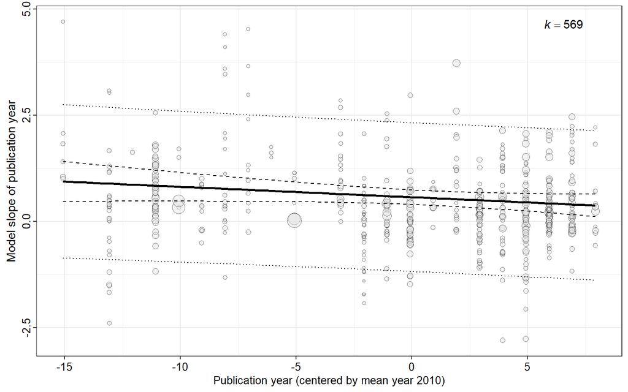

Figure 1. Bubble plot showing the relationship between publication year and effect size magnitude

```r
de <- bubble_plot(pub_bias_test, mod = "Year.c",
                  xlab = "Publication year (centered by mean year 2010)", ylab = "Model slope of publication year",
                  group = "ID",
                  data = montagano.et.al.2019.ecol.letts.dat, legend.pos = "none") +
                  theme(axis.text.x = element_text(size = 10, colour = "black"),
                        axis.text.y = element_text(size = 10, colour = "black"),
                        axis.title.x = element_text(size = 10, colour = "black"),
                        plot.title = element_text(size = 10, colour = "black"))
de
```

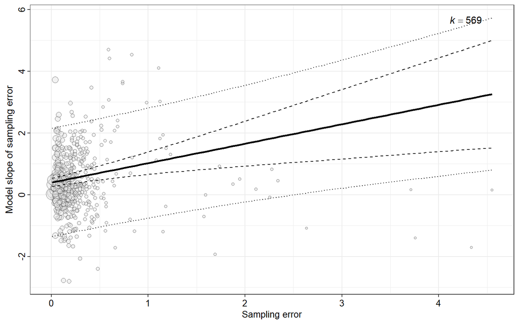

Figure 2. Bubble plot showing the relationship between sampling error (inverse precision) anf effect size magnitude

```r
sse <- bubble_plot(pub_bias_test, mod = "sei",
                   xlab = "Sampling error", ylab = "Model slope of sampling error",
                   group = "ID",
                   data = montagano.et.al.2019.ecol.letts.dat, legend.pos = "none") +
                   theme(axis.text.x = element_text(size = 10, colour = "black"),
                         axis.text.y = element_text(size = 10, colour = "black"),
                         axis.title.x = element_text(size = 10, colour = "black"),
                         plot.title = element_text(size = 10, colour = "black"))
sse
```

Practitioners can modify the above code to identify publication bias (small-study effect and decline effect) and (visually) report the associated results. If you prefer an `rmd` version of the code, please refer to our [Github repository: Yefeng0920/decline_effect_Ecology](https://github.com/Yefeng0920/decline_effect_Ecology). If you are after a comprehensive theoretical knowledge on the publication bias test in ecology and evolution, we recommend you to thoroughly read our recent methodological paper published in *Methods in Ecology and Evolution* (Nakagawa et al. (2022)). In this paper, we summarized the current practice of publication vias testing in ecology and evolution; we also proposed the multilevel multi-moderator meta-regression method approach.

# References

Costello, L., and J. W. Fox. 2022. Decline effects are rare in ecology. Ecology:e3680.

Koricheva, J., and E. Kulinskaya. 2019. Temporal instability of evidence base: A threat to policy making? Trends in ecology & evolution 34:895–902.

Montagano, L., S. J. Leroux, M.-A. Giroux, and N. Lecomte. 2019. The strength of ecological subsidies across ecosystems: A latitudinal gradient of direct and indirect impacts on food webs. Ecology letters 22:265–274.

Nakagawa, S., M. Lagisz, M. D. Jennions, J. Koricheva, D. W. Noble, T. H. Parker, A. Sánchez-Tójar, Y. Yang, and R. E. O’Dea. 2022. Methods for testing publication bias in ecological and evolutionary meta-analyses. Methods in Ecology and Evolution 13:4–21.

Nakagawa, S., M. Lagisz, R. E. O’Dea, J. Rutkowska, Y. Yang, D. W. Noble, and A. M. Senior. 2021. The orchard plot: Cultivating a forest plot for use in ecology, evolution, and beyond. Research Synthesis Methods 12:4–12.

Nakagawa, S., and E. S. Santos. 2012. Methodological issues and advances in biological meta-analysis. Evolutionary Ecology 26:1253–1274.

Rodgers, M. A., and J. E. Pustejovsky. 2021. Evaluating meta-analytic methods to detect selective reporting in the presence of dependent effect sizes. Psychological methods 26:141.

Viechtbauer, W. 2010. Conducting meta-analyses in r with the metafor package. Journal of statistical software 36:1–48.